# Mpls Police Stop Data

Richard Bamattre

2020-12-22

**Purpose**

Apply Stanford’s Open Policing methodology on Mpls Police Data.

https://openpolicing.stanford.edu/

They have an R script for Saint Paul but not Mpls.

**Description**

**Data Sources**

Minneapolis Police Stop Data: https://opendata.minneapolismn.gov/datasets/police-stop-data

*Other Notes*

*Change log*

```r
## Load libraries

# read
library(tidycensus); census_api_key("0c5d9fddc67544f23d3fa524660c9d81d4be2c90") # add API key here

# wrangle
library(tidyverse)
library(lubridate) # work with dates and times

# viz
library(janitor) # clean names and make nice tables
library(gghighlight)
library(ggthemes)
library(gt) # nice tables

# model
library(sf) # GIS

# export

## Custom functions

knitr::opts_chunk$set(warning = FALSE, message = FALSE)
```

# Read

Get police stop data.

Use an API link (ArcGIS) to directly download the latest geojson using st_read

Looking at the first rows of the data:

```r
stop <- st_read("https://opendata.arcgis.com/datasets/215b4b543d894750aef86c725b56ee2a_0.geojson")
head(stop)
```

```
## Simple feature collection with 6 features and 19 fields
## geometry type:  POINT
## dimension:      XY
## bbox:           xmin: -93.28807 ymin: 44.90617 xmax: -93.24741 ymax: 45.02484
## geographic CRS: WGS 84
##   OBJECTID masterIncidentNumber        responseDate reason
## 1        1            16-395258 2016-10-31 17:40:47
## 2        2            16-395296 2016-10-31 18:06:36
## 3        3            16-395326 2016-10-31 18:20:54
## 4        4            16-395328 2016-10-31 18:23:20
## 5        5            16-395333 2016-10-31 18:26:05
## 6        6            16-395364 2016-10-31 18:45:31   <NA>
##                       problem     callDisposition citationIssued personSearch
## 1       Suspicious Person (P)         BKG-Booking                         YES
## 2 Traffic Law Enforcement (P)          TAG-Tagged                          NO
```

[output cut: 25 more lines]

# Overview of the Data

How many total stops? Distinct count of master incident numbers.

```r
n_distinct(stop$masterIncidentNumber)
```

```
## [1] 171935
```

What’s the date range?

```r
min(stop$responseDate)
```

```
## [1] "2016-10-31 17:40:47 CDT"
```

```r
max(stop$responseDate)
```

```
## [1] "2021-01-12 21:26:47 CST"
```

```r
stop2 <- stop %>%
  filter(year(responseDate) >= 2017,
         year(responseDate) < 2021) %>%
  as_tibble() %>%
  select(-geometry)
```

For now, look at vehicular stops. Try doing pedestrian stops later.

```r
stop2 %>%
  tabyl(reason) %>%
  adorn_pct_formatting() %>%
  gt()
```

| reason | n | percent | valid_percent |
| --- | --- | --- | --- |
|  | 10432 | 6.3% | 7.2% |
| Citizen / 9-1-1 | 42854 | 26.0% | 29.6% |
| Equipment Violation | 20871 | 12.7% | 14.4% |
| Investigative | 28823 | 17.5% | 19.9% |
| Moving Violation | 41674 | 25.3% | 28.8% |
| NA | 19887 | 12.1% | - |

```r
stop2 %>%
  tabyl(problem) %>%
  adorn_pct_formatting() %>%
  gt()
```

| problem | n | percent |
| --- | --- | --- |
| Attempt Pick-Up (P) | 3643 | 2.2% |
| Curfew Violations (P) | 112 | 0.1% |
| Suspicious Person (P) | 45784 | 27.8% |
| Suspicious Vehicle (P) | 36458 | 22.2% |
| Traffic Law Enforcement (P) | 78492 | 47.7% |
| Truancy (P) | 52 | 0.0% |

What’s the interaction between reasons and problems?

```r
stop2 %>%
  tabyl(reason, problem) %>%
  gt()
```

| reason | Attempt Pick-Up (P) | Curfew Violations (P) | Suspicious Person (P) | Suspicious Vehicle (P) | Traffic Law Enforcement (P) | Truancy (P) |
| --- | --- | --- | --- | --- | --- | --- |
|  | 220 | 6 | 1830 | 2004 | 6364 | 8 |
| Citizen / 9-1-1 | 1196 | 16 | 22804 | 18590 | 237 | 11 |
| Equipment Violation | 2 | 1 | 332 | 866 | 19670 | 0 |
| Investigative | 1130 | 69 | 12723 | 8877 | 6001 | 23 |
| Moving Violation | 0 | 1 | 878 | 1912 | 38883 | 0 |
| NA | 1095 | 19 | 7217 | 4209 | 7337 | 10 |

### Missing data

Do we know why many stop reasons are NA? Race and Vehicle/Person search for these are NA as well, so drop from the data.

```r
stop2 %>%
  filter(is.na(reason)) %>%
  tabyl(race)
```

```
##  race     n percent valid_percent
##  <NA> 19887       1            NA
```

### Filtering data

Does it make sense to include both Suspicious Vehicles and Traffic Law Enforcement as problems? Also filter out missing reasons.

How many stops now?

```r
stop_v <- stop2 %>%
  filter(problem %in% c("Suspicious Vehicle (P)", "Traffic Law Enforcement (P)"),
         !is.na(reason))

n_distinct(stop_v$masterIncidentNumber) # only one incident per row, so we can do a row count
```

```
## [1] 103404
```

How many by year?

```r
stop_v %>%
  mutate(year = year(responseDate)) %>%
  count(year) %>%
  gt()
```

| year | n |
| --- | --- |
| 2017 | 32715 |
| 2018 | 29140 |
| 2019 | 24008 |
| 2020 | 17541 |

How many stops by race?

```r
stop_v %>%
  tabyl(race) %>%
  adorn_pct_formatting() %>%
  gt()
```

| race | n | percent |
| --- | --- | --- |
| Asian | 1705 | 1.6% |
| Black | 37962 | 36.7% |
| East African | 6388 | 6.2% |
| Latino | 4712 | 4.6% |
| Native American | 1647 | 1.6% |
| Other | 2673 | 2.6% |
| Unknown | 21147 | 20.5% |
| White | 27170 | 26.3% |

Stops by race over the years:

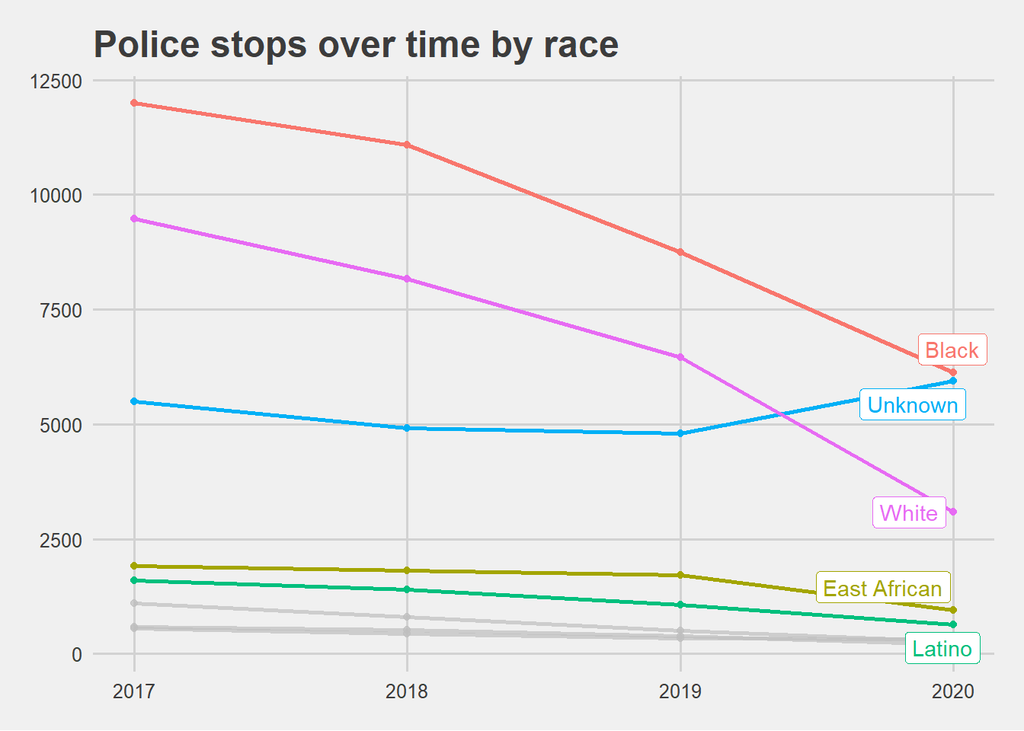

```r
stop_v %>%
  mutate(year = year(responseDate)) %>%
  count(year, race) %>%
  ggplot(aes(year, n, color = race)) +
    geom_line(size = 1) +
    geom_point() +
    gghighlight(race %in% c("White", "Black", "East African", "Unknown",
                            "Latino", NA)) +
    theme_fivethirtyeight() +
    labs(title = "Police stops over time by race")
```

# Benchmark Test

Get a population as a baseline to compare stop rates. Are black/East African drivers stopped proportionally more than other drivers?

Get the population estimates from the census using tidycensus

```r
# list of variables to get and their names
var <- c(
  "Total" = "DP05_0033",
  "White" = "DP05_0077", # using white non-hispanic
  "Black" = "DP05_0038",
  "Native American" = "DP05_0039",
  "Asian" = "DP05_0044",
  "Latino" = "DP05_0071", # hispanic/latinx of any race
  "Other" = "DP05_0057" # some other race
)

# query census API with list of variables

mpls_race <- get_acs(
  geography = "place", state = "MN",
  year = 2019,
  survey = "acs5", # get 5 year estimates - smaller margin of error and more appropriate for multi-year data
  variables = var
) %>%
  filter(str_detect(NAME, "Minneapolis")) %>% # get only Minneapolis from other MN places
  select(-c(moe, GEOID, NAME))

# get percentages (out of total)

mpls_race %>%
  mutate(total = estimate[variable == "Total"]) %>%
  mutate(prop = estimate / total) %>%
  select(-c(total)) %>%
  gt() %>%
    fmt_percent(
      columns = vars(prop),
      decimals = 1
    )
```

| variable | estimate | prop |
| --- | --- | --- |
| Total | 420324 | 100.0% |
| Black | 80664 | 19.2% |
| Native American | 5956 | 1.4% |
| Asian | 24961 | 5.9% |
| Other | 20915 | 5.0% |
| Latino | 40432 | 9.6% |
| White | 252180 | 60.0% |

To match census data, combine East African with black drivers.

```r
stop_v2 <- stop_v %>%
  mutate(race2 = if_else(race == "East African", "Black", race))

stop_v2 %>%
  tabyl(race2) %>%
  adorn_pct_formatting() %>%
  gt()
```

| race2 | n | percent |
| --- | --- | --- |
| Asian | 1705 | 1.6% |
| Black | 44350 | 42.9% |
| Latino | 4712 | 4.6% |
| Native American | 1647 | 1.6% |
| Other | 2673 | 2.6% |
| Unknown | 21147 | 20.5% |
| White | 27170 | 26.3% |

## Stop Rates

What is the rate of police stops considering the population of races in Mpls?

Not sure what to do about Unknown/NA - quite a few in this category

```r
stop_v2 %>%
  count(race2) %>%
  left_join(mpls_race, by = c("race2" = "variable")) %>%
  mutate(stop_rate = n / estimate) %>%
  gt() %>%
    fmt_number(
      columns = vars(stop_rate),
      decimals = 2
    )
```

| race2 | n | estimate | stop_rate |
| --- | --- | --- | --- |
| Asian | 1705 | 24961 | 0.07 |
| Black | 44350 | 80664 | 0.55 |
| Latino | 4712 | 40432 | 0.12 |
| Native American | 1647 | 5956 | 0.28 |
| Other | 2673 | 20915 | 0.13 |
| Unknown | 21147 | NA | NA |
| White | 27170 | 252180 | 0.11 |

## Search Rates

What proportion of drivers of each race are searched (vehicle or person)?

```r
stop_v2 %>%
  group_by(race2) %>%
  summarize(
    search_rate = mean(vehicleSearch == "YES", na.rm = TRUE),
    frisk_rate = mean(personSearch == "YES", na.rm = TRUE)
  ) %>%
  gt() %>%
    fmt_number(
      columns = vars(search_rate, frisk_rate),
      decimals = 2
    )
```

| race2 | search_rate | frisk_rate |
| --- | --- | --- |
| Asian | 0.06 | 0.06 |
| Black | 0.16 | 0.17 |
| Latino | 0.09 | 0.09 |
| Native American | 0.25 | 0.31 |
| Other | 0.09 | 0.09 |
| Unknown | 0.04 | 0.02 |
| White | 0.05 | 0.06 |

## Caveats

Here the caveats from the [Stanford Open Policing Project](https://openpolicing.stanford.edu/tutorials/) are important. These rates are not in themselves evidence of bias or discrimination because we don’t know the underlying rates of breaking traffic laws or committing crimes. Also it may reflect differences in transportation across races.

# Outcome Test

## Hit Rate (Citations and Booking)

Here we could look at hit rate or the contraband recovery rate - how often searches were justified by finding contraband.

We don’t have that in this data set. We do have whether a citation was issued (as its own variable) and booking as part of the call disposition variable.

Should we look at vehicle and person search (frisking) separately?

```r
stop_v2 %>%
  tabyl(personSearch, vehicleSearch) %>%
  gt()
```

| personSearch | NO | YES |
| --- | --- | --- |
| NO | 90679 | 2157 |
| YES | 1924 | 8644 |

Actually, vehicle combined with person searches are more common than either search alone. To simplify, we can create a variable specifying whether any type of search is conducted.

```r
stop_v3 <- stop_v2 %>%
  mutate(any_search = if_else(personSearch == "YES" | vehicleSearch == "YES",
                              1, 0))

stop_v3 %>%
  filter(any_search == 1) %>%
  group_by(race2) %>%
  summarize(
    citation_rate = mean(citationIssued == "YES", na.rm = TRUE),
    book_rate = mean(callDisposition == "BKG-Booking", na.rm = TRUE)
  ) %>%
  gt() %>%
    fmt_number(
      columns = vars(citation_rate, book_rate),
      decimals = 2
    )
```

| race2 | citation_rate | book_rate |
| --- | --- | --- |
| Asian | 0.13 | 0.49 |
| Black | 0.18 | 0.32 |
| Latino | 0.27 | 0.36 |
| Native American | 0.10 | 0.53 |
| Other | 0.15 | 0.38 |
| Unknown | 0.12 | 0.11 |
| White | 0.16 | 0.45 |

Here lower rates could signal discrimination. If black drivers are stopped but only cited or booked 5% of the time, and white drivers 50% of the time, “would lead us to believe that officers made sure they were certain white individuals had contraband before deciding to search, but that they were searching black individuals on a whiff of evidence” (Stanford Open Policing Project).

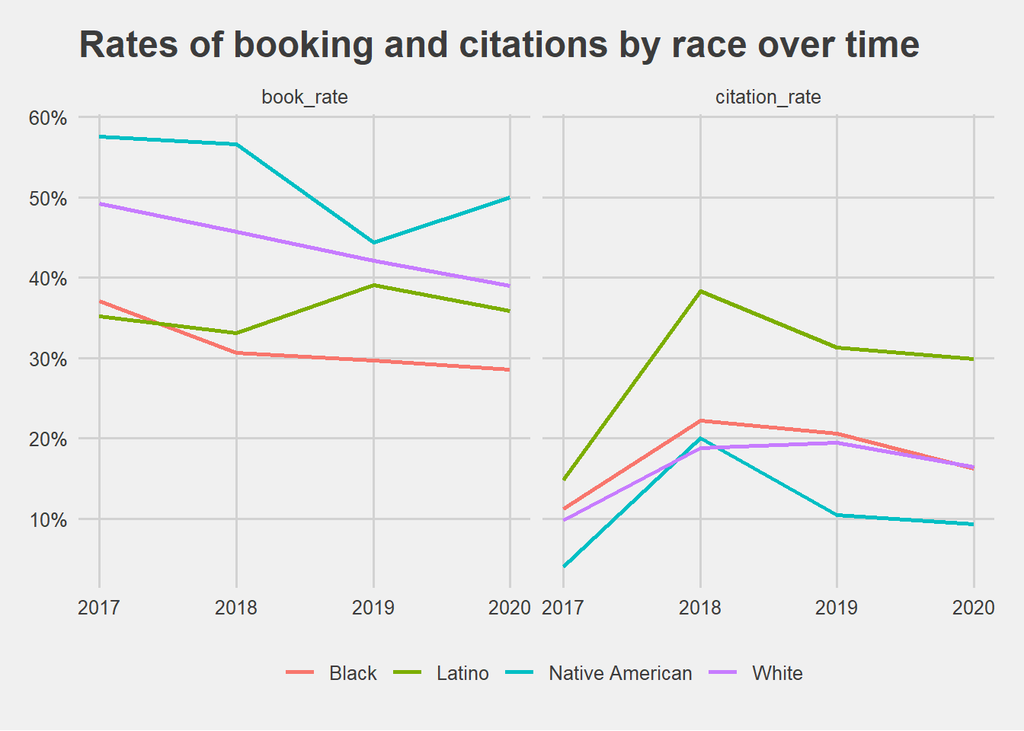

```r
stop_v3 %>%
  filter(any_search == 1) %>%
  mutate(year = year(responseDate)) %>%
  group_by(year, race2) %>%
  summarize(
    citation_rate = mean(citationIssued == "YES", na.rm = TRUE),
    book_rate = mean(callDisposition == "BKG-Booking", na.rm = TRUE)
  ) %>%
  pivot_longer(citation_rate:book_rate, names_to = "rate", values_to = "value") %>%
  filter(race2 %in% c("White", "Black", "Native American", "Latino")) %>%
  ggplot(aes(year, value, color = race2)) +
    geom_line(size = 1) +
    facet_wrap(~ rate) +
    theme_fivethirtyeight() +
    labs(title = "Rates of booking and citations by race over time",
         color = "") +
    scale_y_continuous(labels = scales::percent_format(accuracy = 1))
```

## By Neighborhood

Does the citation or booking rate differ across police precincts? There are only 5 precincts, may not be useful to see. What about Minneapolis neighborhoods?

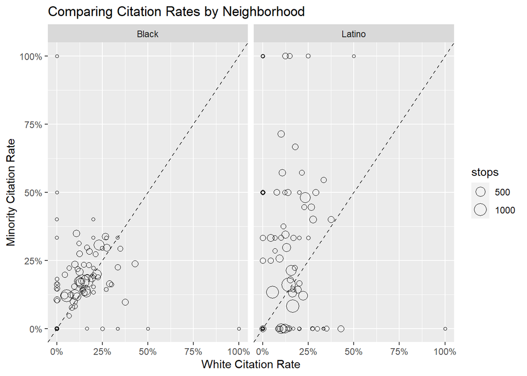

```r
rates <- stop_v3 %>%
  filter(any_search == 1) %>%
  group_by(race2, neighborhood) %>%
  summarize(
    citation_rate = mean(citationIssued == "YES", na.rm = TRUE),
    book_rate = mean(callDisposition == "BKG-Booking", na.rm = TRUE)
  )

# What are the total stops by neighborhood?

stops_by_nh <- stop_v3 %>%
  filter(any_search == 1) %>%
  group_by(neighborhood) %>%
  summarize(stops = n())

# make a tidy data frame with white rates, and minority rates per neighborhood

citation_rate <- rates %>%
  ungroup() %>%
  select(-book_rate) %>%
  filter(race2 %in% c("White", "Black", "Latino"),
         !is.na(neighborhood)) %>%
  pivot_wider(names_from = "race2", values_from = "citation_rate",
              values_fill = 0) %>%
  left_join(stops_by_nh, by = "neighborhood") %>%
  pivot_longer(c(Black:Latino), names_to = "minority_race",
               values_to = "minority_citation_rate") %>%
  rename(white_citation_rate = White)

book_rate <- rates %>%
  ungroup() %>%
  select(-citation_rate) %>%
  filter(race2 %in% c("White", "Black", "Latino"),
         !is.na(neighborhood)) %>%
  pivot_wider(names_from = "race2", values_from = "book_rate",
              values_fill = 0) %>%
  left_join(stops_by_nh, by = "neighborhood") %>%
  pivot_longer(c(Black:Latino), names_to = "minority_race",
               values_to = "minority_book_rate") %>%
  rename(white_book_rate = White)

citation_rate %>%
  ggplot(aes(x = white_citation_rate, y = minority_citation_rate)) +
    geom_point(aes(size = stops), pch = 21) +
    geom_abline(slope = 1, intercept = 0, linetype = "dashed") +
    facet_wrap(~ minority_race) +
    scale_y_continuous(labels = scales::percent_format()) +
    scale_x_continuous(labels = scales::percent_format()) +
    labs(y = "Minority Citation Rate", x = "White Citation Rate",
         title = "Comparing Citation Rates by Neighborhood")
```

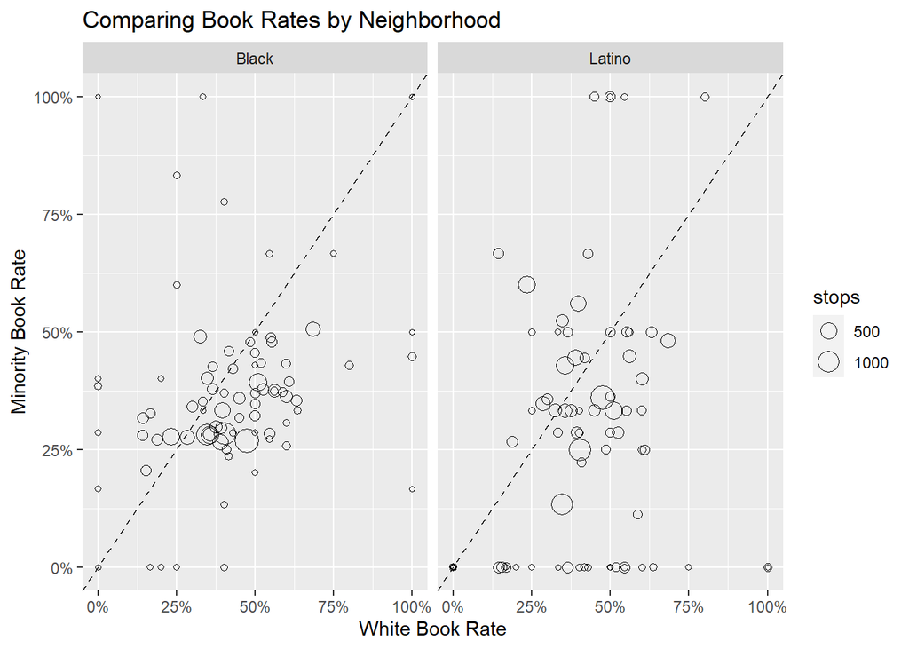

```r
book_rate %>%
  ggplot(aes(x = white_book_rate, y = minority_book_rate)) +
    geom_point(aes(size = stops), pch = 21) +
    geom_abline(slope = 1, intercept = 0, linetype = "dashed") +
    facet_wrap(~ minority_race) +
    scale_y_continuous(labels = scales::percent_format()) +
    scale_x_continuous(labels = scales::percent_format()) +
    labs(y = "Minority Book Rate", x = "White Book Rate",
         title = "Comparing Book Rates by Neighborhood")
```

For book rates though, the majority of neighborhoods, particularly those with the most stops, have lower rates for black/Latinx drivers.

This signals that officers are applying lower threshholds to minority drivers when it comes to offenses that are bookable. I think.